# 26 - Class Notes

Fadel M Megahed

April 28, 2021

# 1 Preface

## 1.1 What we Learned Last Class

1. Use regression to account for seasonality in a time series.
2. Compare the performance of the regression model with that obtained from `auto.arima()`.

## 1.2 Required Packages

In the code chunk below, we use the `pacman` package to load the required packages and install them if necessary.

```r
if(require(pacman)==FALSE) install.packages("pacman")
```

```r
pacman::p_load(tidyverse,
               magrittr, # for the two-way pipe
               fpp2, # accuracy() function, Arima(), auto.arima(),
               astsa, # package is for the required data
               plotly, # for interactive graphs
               ggpubr)

source('https://raw.githubusercontent.com/fmegahed/businessForecasting/master/lectures/24%20-%20Time%20Series%20Regression%20(Cont)/resPlotTS.R') # loading our resPlot function from Last Class
```

## 1.3 Main Learning Outcomes for Today’s Class

1. Combine regression with ARIMA models to model a time series with autocorrelated errors.
2. Use the xreg argument to combine ARIMA models with regression predictors.

# 2 Combining Regression with ARIMA Models

## 2.1 Preface

We have learned to fit ARIMA models to predict a series from itself, removing the autocorrelation from a series. These methods are useful, but don’t allow us to combine “outside” information to boost our forecast.

Now we will discuss combining regression (**outside information**) and ARIMA models (**inside information**) to forecast a time series.

A multiple regression model takes on the form:
$$Y_t = \beta_0 + \beta_1 x_{t,1} + \beta_2 x_{t,2} + \dots + \beta_q x_{t,q} + \epsilon_t,$$
where we typically assume that $\epsilon_t$ is independent, identically distributed white noise (normally distributed).

## 2.2 What we Learned from the J&J Example

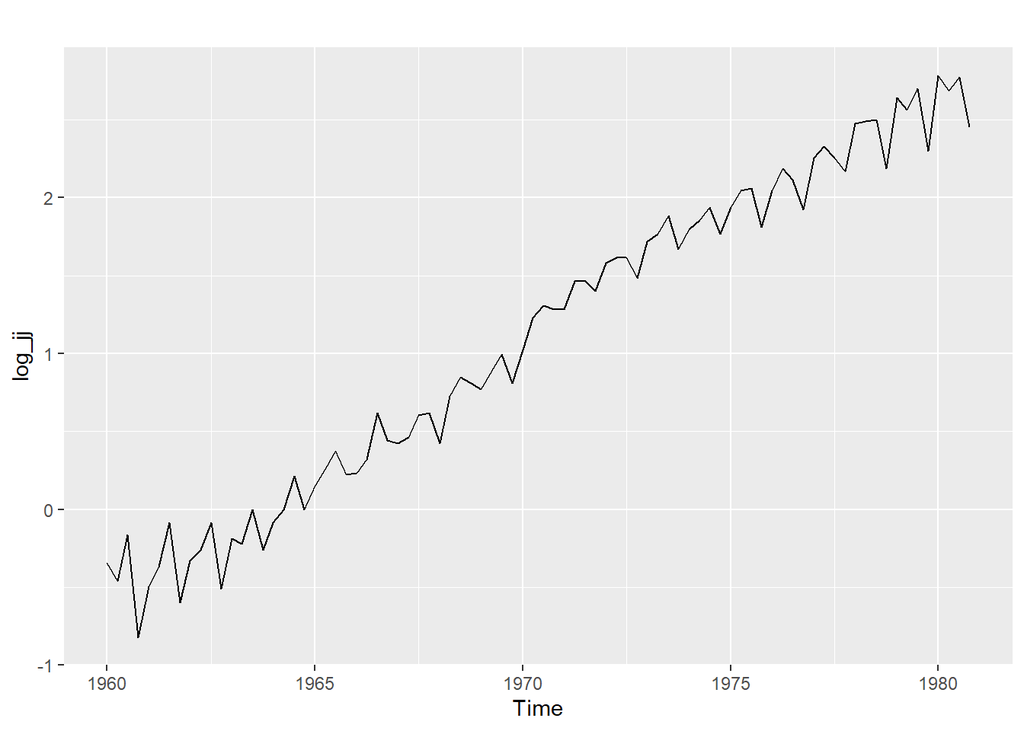

```r
log_jj = log(jj) # to make the data more linear and stablize the variance a bit
autoplot(log_jj)
```

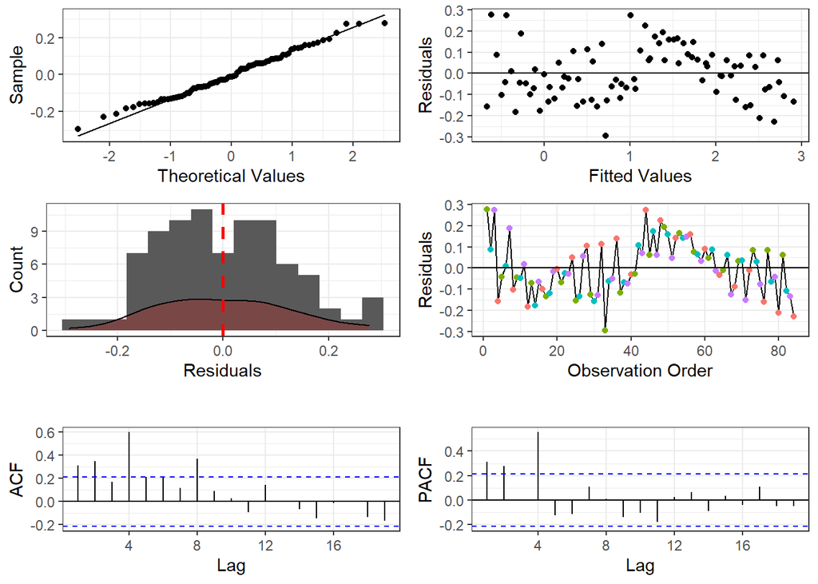

```r
t = time(log_jj) # capture/create a time index
season = cycle(log_jj) %>% factor()

model4 = tslm(log_jj ~ trend + season) # fitting a regression model with season and trend

modelSummary = summary(model4) # saving the summary output into the object modelSummary

resplot(res = model4$residuals, fit = model4$fitted.values, freq = 4) # visualizing the residuals and fitted values
```

**Based on the J&J Example**, when our dependent and independent variables are observed over time, $\epsilon_t$ **is often correlated over time**. *In such cases, the assumptions of iid residuals are not met and the fitted regression models should not be used.*

## 2.3 Possible Solution

Thus, we will restate our model as follows:

$$Y_t = \beta_0 + \beta_1 x_{t,1} + \beta_2 x_{t,2} + \dots + \beta_q x_{t,q} + \eta_t,$$

where $\eta_t$ **follows an ARIMA model.**

**If we are using an AR(1) model for the residuals**, in this case our model would look as follows

$$Y_t = \beta_0 + \beta_1 x_{t,1} + \beta_2 x_{t,2} + \dots + \beta_q x_{t,q} + \eta_t,$$

where $\eta_t = \delta + \phi_1 \eta_{t-1} + \epsilon_t$ **follows an AR(1) model.**

**If we were to use an ARMA(1,1) model for the residuals**, in this case our model would look as follows
$$Y_t = \beta_0 + \beta_1 x_{t,1} + \beta_2 x_{t,2} + \dots + \beta_q x_{t,q} + \eta_t,$$
where $\eta_t = \delta + \phi_1 \eta_{t-1} + \epsilon_t - \theta_1 \epsilon_{t-1}$ **follows an ARMA(1,1) model.**

## 2.4 Using R to Fit The Model

We will use the “uschange” data from the `fpp2` package to forecast changes in personal consumption expenditures based on personal disposable income from 1970 to 2016.

**Process:**

1. Start by plotting the quarterly changes in US consumption and personal income
2. Fit a regression with Y = change in consumption and X = Change in personal income, with autocorrelated errors – using the `auto.arima()`. The **new part** is that we would be using the argument `xreg` for the predictor/explanatory variables.
3. Check the residual plots to ensure the assumptions of the model are met

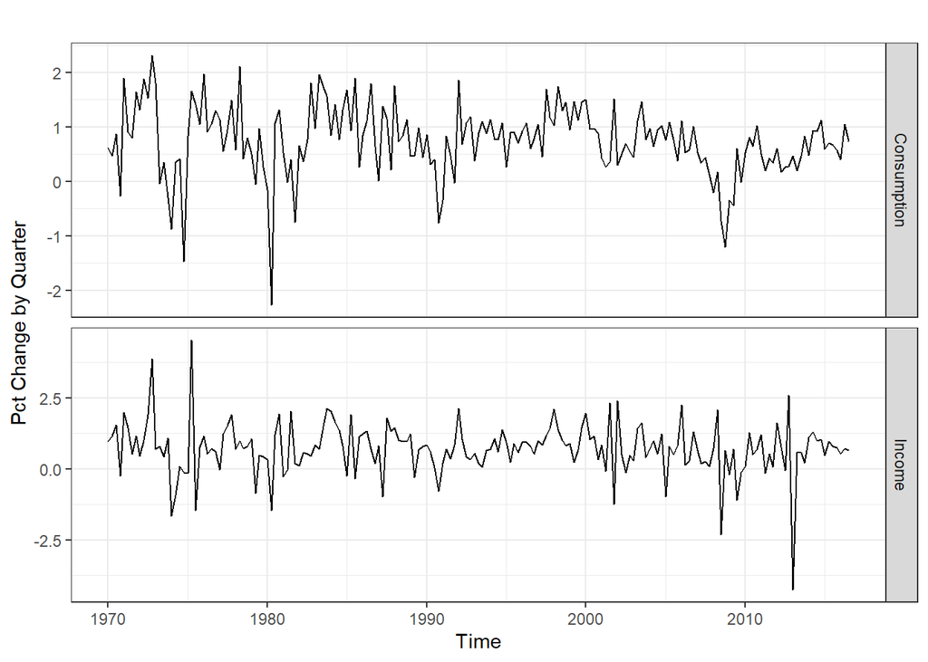

```r
uschange = uschange

autoplot(uschange[, c('Consumption', 'Income')],
         facets = TRUE) + labs(y = "Pct Change by Quarter")# just plotting the data; argument facets = T creates the panels
```

```r
reg1Fit = auto.arima(uschange[,'Consumption'], xreg = uschange[, 'Income'])
summary(reg1Fit)
```

```
## Series: uschange[, "Consumption"]
## Regression with ARIMA(1,0,2) errors
##
## Coefficients:
##          ar1      ma1     ma2  intercept    xreg
##       0.6922  -0.5758  0.1984     0.5990  0.2028
## s.e.  0.1159   0.1301  0.0756     0.0884  0.0461
##
## sigma^2 estimated as 0.3219:  log likelihood=-156.95
## AIC=325.91   AICc=326.37   BIC=345.29
##
## Training set error measures:
##                       ME      RMSE       MAE     MPE     MAPE      MASE
## Training set 0.001714366 0.5597088 0.4209056 27.4477 161.8417 0.6594731
##                     ACF1
## Training set 0.006299231
```

**From the above example, our regression equation would look like this:**
$$Consumption_{t} = 0.5990 + 0.2028Income_{t} + \eta_t,$$
where $\eta_t = \delta + \phi_1 \eta_{t-1} + \epsilon_t + \theta_1 \epsilon_{t-1} + \theta_2 \epsilon_{t-2}$ **follows an ARMA(1,2) model.**

**Investigating the residuals from the model:**

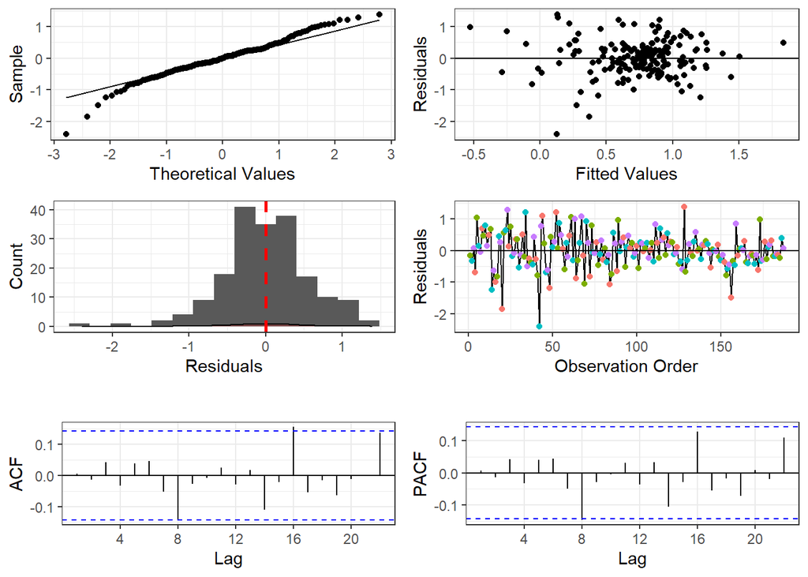

```r
resplot(res = reg1Fit$residuals, fit = reg1Fit$fitted, freq = 4)
```

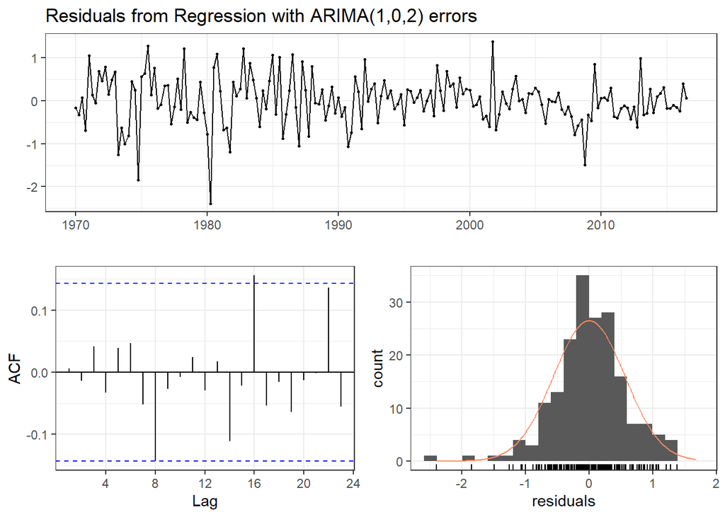

```
##
##  Ljung-Box test
##
## data:  Residuals from Regression with ARIMA(1,0,2) errors
## Q* = 5.8916, df = 3, p-value = 0.117
##
## Model df: 5.   Total lags used: 8
```

```r
checkresiduals(reg1Fit)
```

# 3 In-Class Activities

```r
# Solutions for the Questions
# (1a) Extrapolative forecasting using auto.arima (i.e., only the time-series for Consumption)
model1 = auto.arima(uschange[, 'Consumption'])
summary(model1)
```

```
## Series: uschange[, "Consumption"]
## ARIMA(1,0,3)(1,0,1)[4] with non-zero mean
##
## Coefficients:
##           ar1     ma1     ma2     ma3     sar1    sma1    mean
##       -0.3548  0.5958  0.3437  0.4111  -0.1376  0.3834  0.7460
## s.e.   0.1592  0.1496  0.0960  0.0825   0.2117  0.1780  0.0886
##
## sigma^2 estimated as 0.3481:  log likelihood=-163.34
## AIC=342.67   AICc=343.48   BIC=368.52
##
## Training set error measures:
##                        ME      RMSE      MAE      MPE     MAPE      MASE
## Training set 0.0008112515 0.5788296 0.432668 65.97513 187.9184 0.6779023
##                      ACF1
## Training set -0.007489122
```

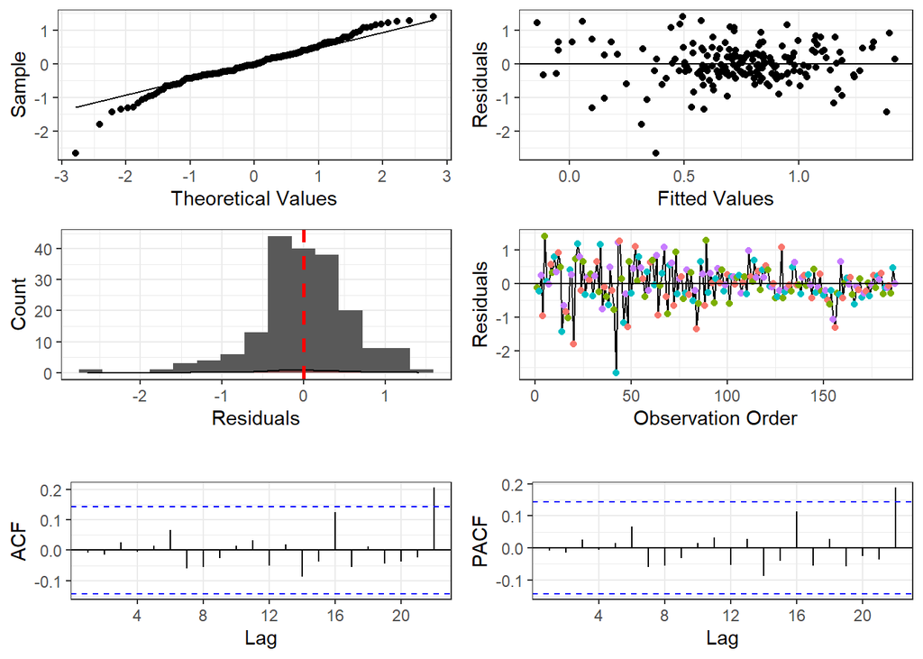

```r
resplot(res = model1$residuals, fit = model1$fitted, freq = 4)
```

```r
# (1b) Reg with Income and Savings and ARIMA structure imposed on the error term
model2 = auto.arima(uschange[,'Consumption'], xreg = uschange[, c('Income', 'Savings') ])
summary(model2)
```

```
## Series: uschange[, "Consumption"]
## Regression with ARIMA(0,0,0) errors
##
## Coefficients:
##       intercept  Income  Savings
##          0.2227  0.8171  -0.0512
## s.e.     0.0361  0.0389   0.0027
##
## sigma^2 estimated as 0.1218:  log likelihood=-66.98
## AIC=141.96   AICc=142.18   BIC=154.88
##
## Training set error measures:
##                         ME      RMSE       MAE      MPE     MAPE      MASE
## Training set -9.130799e-15 0.3461899 0.2428978 16.88803 70.14026 0.3805712
##                     ACF1
## Training set -0.05573023
```

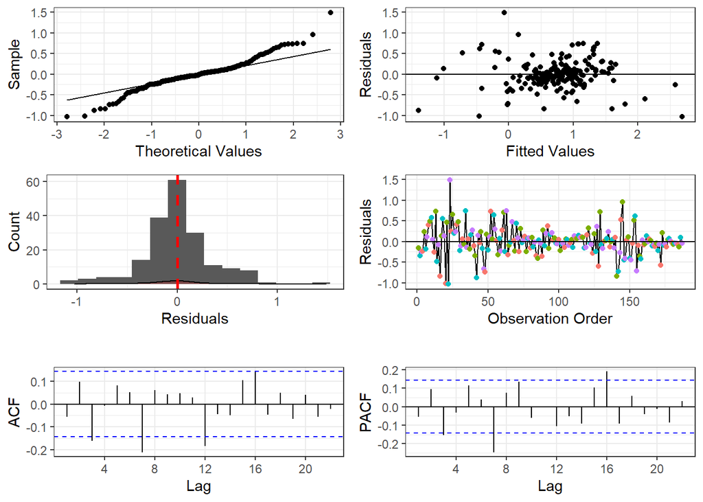

```r
resplot(res = model2$residuals, fit = model2$fitted, freq = 4)
```

```r
# (1c) Lm using both income and savings
model3 = lm(uschange[,'Consumption'] ~ uschange[,'Income'] + uschange[,'Savings'])
summary(model3)
```

```
##
## Call:
## lm(formula = uschange[, "Consumption"] ~ uschange[, "Income"] +
##     uschange[, "Savings"])
##
## Residuals:
##      Min       1Q   Median       3Q      Max
## -1.02827 -0.15851 -0.01347  0.13629  1.48817
##
## Coefficients:
##                        Estimate Std. Error t value Pr(>|t|)
## (Intercept)            0.222697   0.036372   6.123 5.43e-09 ***
## uschange[, "Income"]   0.817142   0.039219  20.835  < 2e-16 ***
## uschange[, "Savings"] -0.051238   0.002673 -19.172  < 2e-16 ***
## ---
## Signif. codes:  0 '***' 0.001 '**' 0.01 '*' 0.05 '.' 0.1 ' ' 1
##
## Residual standard error: 0.349 on 184 degrees of freedom
## Multiple R-squared:  0.7194, Adjusted R-squared:  0.7164
## F-statistic: 235.9 on 2 and 184 DF,  p-value: < 2.2e-16
```

```r
# (1d) Income only
model4 = lm(uschange[,'Consumption'] ~ uschange[,'Income'] )
summary(model4)
```

```
##
## Call:
## lm(formula = uschange[, "Consumption"] ~ uschange[, "Income"])
##
## Residuals:
##      Min       1Q   Median       3Q      Max
## -2.40845 -0.31816  0.02558  0.29978  1.45157
##
## Coefficients:
##                      Estimate Std. Error t value Pr(>|t|)
## (Intercept)           0.54510    0.05569   9.789  < 2e-16 ***
## uschange[, "Income"]  0.28060    0.04744   5.915 1.58e-08 ***
## ---
## Signif. codes:  0 '***' 0.001 '**' 0.01 '*' 0.05 '.' 0.1 ' ' 1
##
## Residual standard error: 0.6026 on 185 degrees of freedom
## Multiple R-squared:  0.159,  Adjusted R-squared:  0.1545
## F-statistic: 34.98 on 1 and 185 DF,  p-value: 1.577e-08
```

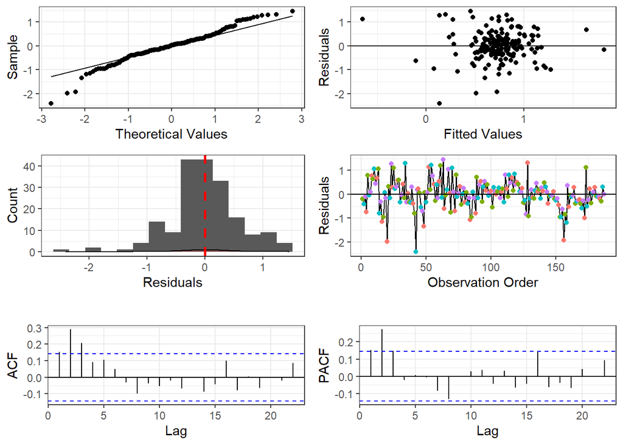

```r
resplot(model4$residuals, model4$fitted.values, freq = 4)
```

```r
# Bonus Question: How to make predictions about future values
predict(reg1Fit, newxreg = c(0.1, -0.2)) # for reg1fit (one predictor)
```

[output not shown]

```r
# Alternatively
forecast(reg1Fit, xreg = c(0.1, -0.2)) # for reg1fit (one predictor)
```

```
##         Point Forecast       Lo 80    Hi 80      Lo 95    Hi 95
## 2016 Q4      0.6591789 -0.06790304 1.386261 -0.4527970 1.771155
## 2017 Q1      0.5998972 -0.13209545 1.331890 -0.5195889 1.719383
```

```r
# For forecast models with multiple predictors, you will have to add the information as a data.matrix
forecast(model2,
         xreg = data.frame( Income = c(0.1, -0.2), Savings = c(0.1, 0.2) ) %>% data.matrix()  )
```

```
##         Point Forecast      Lo 80     Hi 80      Lo 95     Hi 95
## 2016 Q4     0.29928724 -0.1479751 0.7465496 -0.3847415 0.9833160
## 2017 Q1     0.04902102 -0.3982413 0.4962834 -0.6350077 0.7330497
```